# Lab04_ITMD514_05_Patra_Surajit

Surajit Patra

2024-11-03

```r
library(ISLR2)# library(ISLR2)
library(tidyverse)
data("Auto")
head(Auto)
```

```
##   mpg cylinders displacement horsepower weight acceleration year origin
## 1  18         8          307        130   3504         12.0   70      1
## 2  15         8          350        165   3693         11.5   70      1
## 3  18         8          318        150   3436         11.0   70      1
## 4  16         8          304        150   3433         12.0   70      1
## 5  17         8          302        140   3449         10.5   70      1
## 6  15         8          429        198   4341         10.0   70      1
##                        name
## 1 chevrolet chevelle malibu
## 2         buick skylark 320
## 3        plymouth satellite
## 4             amc rebel sst
## 5               ford torino
## 6          ford galaxie 500
```

# Part I (6pts) - Exercise 9 from section 2.3 or the intro to statistical learning book, v2, p56.

Q1. Exercise 9, Section 2.4 Read Section 2.3 from ISLv2. Retrieve the exercise from the book, though I provide it here for ease of access.

This exercise involves the Auto data set studied in the lab. Make sure that the missing values have been removed from the data.

1. Which of the predictors are quantitative, and which are qualitative?

```r
quantitative_predictors <- c("mpg", "cylinders", "displacement", "horsepower", "weight", "acceleration", "year" )
qualitative_predictors <- c("name", "origin")
```

Ans- The quantitative predictors are - mpg, cylinders, displacement, horsepower, weight, acceleration, and year.

Qualitative predictors are - name and origin.

2. What is the range of each quantitative predictor? You can answer this using the range() function.

```r
range_quantitative <- sapply(Auto[, quantitative_predictors], range)
print(range_quantitative)
```

```
##       mpg cylinders displacement horsepower weight acceleration year
## [1,]  9.0         3           68         46   1613          8.0   70
## [2,] 46.6         8          455        230   5140         24.8   82
```

3. What is the mean and standard deviation of each quantitative predictor?

```r
# mean of each quantitative predictor
mean_quantitative <- sapply(Auto[,quantitative_predictors], mean)
print(mean_quantitative)
```

```
##          mpg    cylinders displacement   horsepower       weight acceleration
##    23.445918     5.471939   194.411990   104.469388  2977.584184    15.541327
##         year
##    75.979592
```

```r
# standard dev of each quantitative predictor
stddev_quantitative <- sapply(Auto[,quantitative_predictors], sd)
print(stddev_quantitative)
```

```
##          mpg    cylinders displacement   horsepower       weight acceleration
##     7.805007     1.705783   104.644004    38.491160   849.402560     2.758864
##         year
##     3.683737
```

4. Now remove the 10th through 85th observations. What is the range, mean, and standard deviation of each predictor in the subset of the data that remains?

```r
Auto <- na.omit(Auto)
subset_Auto <- Auto[-(10:85), ]
range_subset <- sapply(subset_Auto[, quantitative_predictors], range)
print(range_subset)
```

```
##       mpg cylinders displacement horsepower weight acceleration year
## [1,] 11.0         3           68         46   1649          8.5   70
## [2,] 46.6         8          455        230   4997         24.8   82
```

```r
mean_subset <- sapply(subset_Auto[, quantitative_predictors], mean)
print(mean_subset)
```

```
##          mpg    cylinders displacement   horsepower       weight acceleration
##    24.404430     5.373418   187.240506   100.721519  2935.971519    15.726899
##         year
##    77.145570
```

```r
stddev_subset <- sapply(subset_Auto[, quantitative_predictors], sd)
print(stddev_subset)
```

```
##          mpg    cylinders displacement   horsepower       weight acceleration
##     7.867283     1.654179    99.678367    35.708853   811.300208     2.693721
##         year
##     3.106217
```

5. Using the full data set, investigate the predictors graphically, using scatterplots or other tools of your choice. Create some plots highlighting the relationships among the predictors. Comment on your findings.

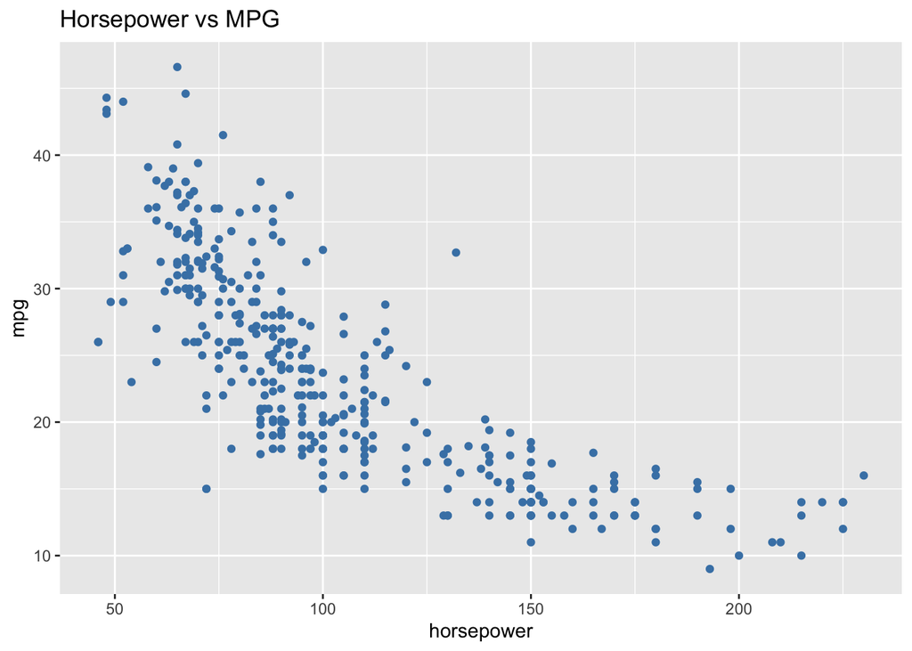

```r
# Scatterplot to show Horsepower vs MPG
ggplot(
  data = Auto,
  aes(x= horsepower, y= mpg))+
  geom_point(color = "steelblue")+
labs(title = "Horsepower vs MPG")
```

Ans- In this scatterplot we can see a negative trend and can see that when the horsepower of a car increases the MPG of a car decreases.

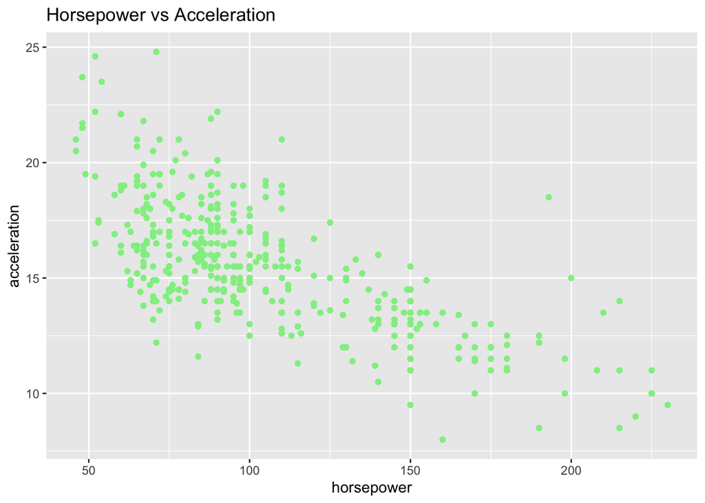

```r
# Scatterplot to show Horsepower vs Acceleration
ggplot(
  data = Auto,
  aes(x= horsepower, y= acceleration))+
  geom_point(color = "lightgreen")+
labs(title = "Horsepower vs Acceleration")
```

Ans- In this scatterplot we can see a negative trend and can see that when the horsepower of a car increases the acceleration time of a car is decreases.

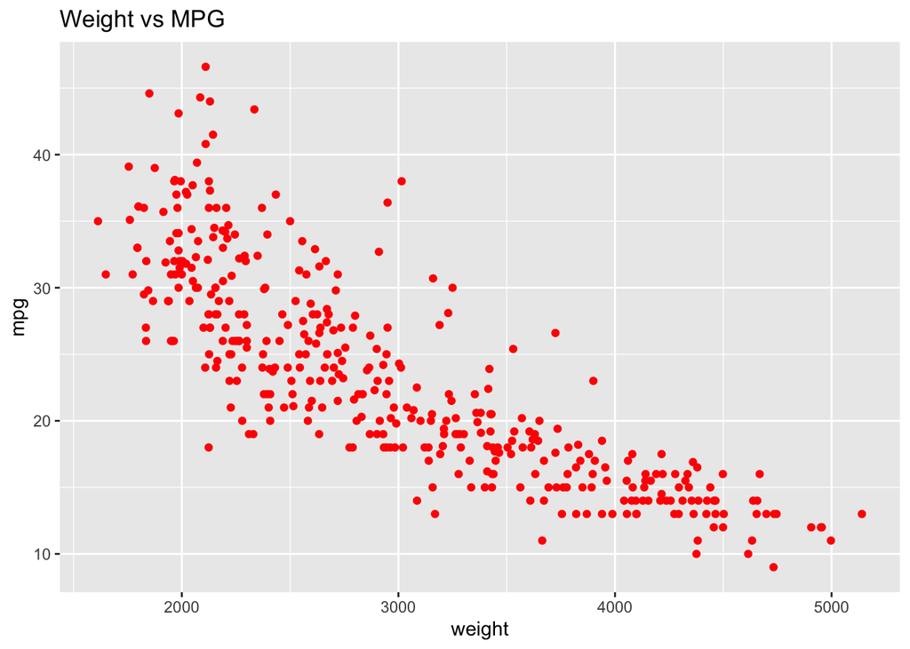

```r
# Scatterplot to show Weight vs MPG
ggplot(
  data = Auto,
  aes(x= weight, y= mpg))+
  geom_point(color = "red")+
labs(title = "Weight vs MPG")
```

Ans- In this scatterplot we can see a negative trend and can see that when the weight of a car increases the MPG of a car is decreases.

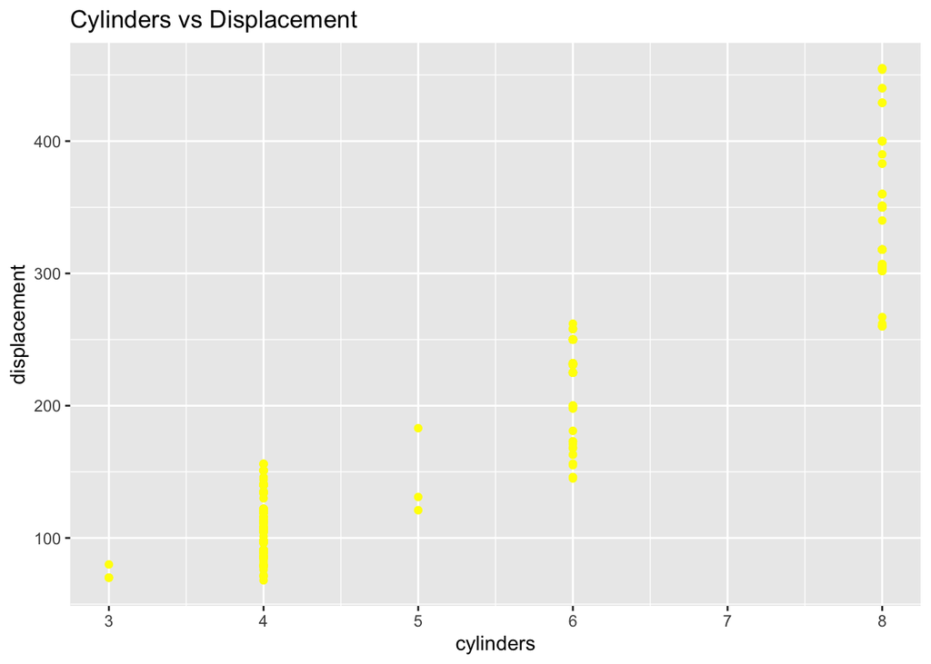

```r
# Scatterplot to show Cylinders vs Displacement
ggplot(
  data = Auto,
  aes(x= cylinders, y= displacement))+
  geom_point(color = "yellow")+
labs(title = "Cylinders vs Displacement")
```

Ans- In this scatterplot we can see a positive trend and can see that when the displacement of a car increases as the number of cylinders increases.

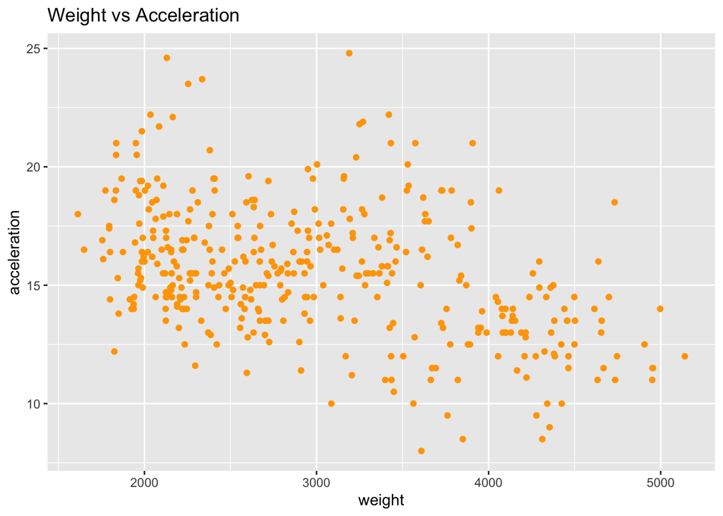

```r
# Scatter plot to show Weight vs Acceleration
ggplot(
  data = Auto,
  aes(x= weight, y= acceleration))+
  geom_point(color = "orange")+
labs(title = "Weight vs Acceleration")
```

Ans- In this scatterplot we can see that most of the cars with less weight took more time to accelerate where as cars with more weight took less time. This could also mean that the power to weight ratio of the light weight cars are not good as compared to the cars with more weight.

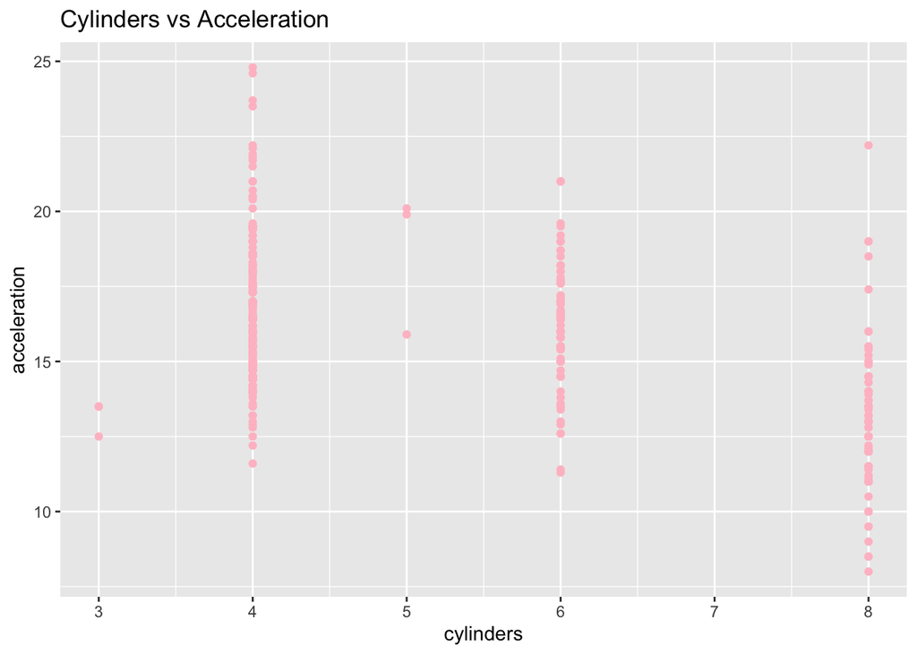

```r
# Scatter plot to show Cylinders vs Acceleration
ggplot(
  data = Auto,
  aes(x= cylinders, y= acceleration))+
  geom_point(color = "pink")+
labs(title = "Cylinders vs Acceleration")
```

Ans- In this scatterplot we can see a negative trend where as the number of cylinders increases the acceleration time start to decrease.

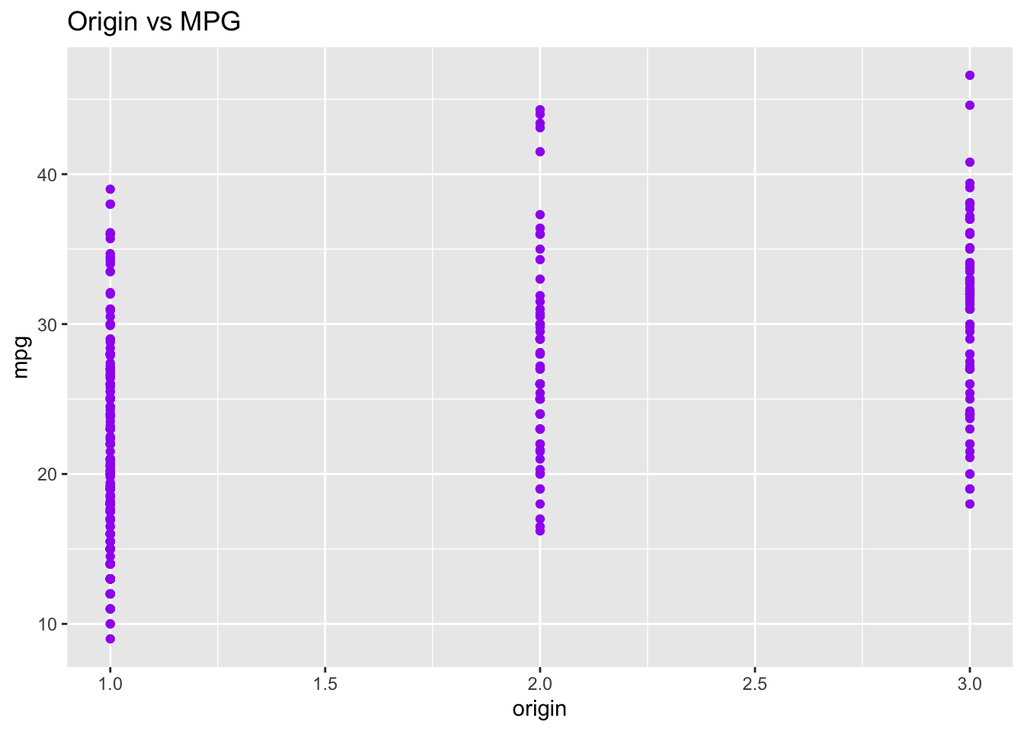

```r
# Scatterplot to show Origin vs mpg
ggplot(
  data = Auto,
  aes(x = origin, y = mpg)) +
  geom_point(color = "purple") +
  labs(title = "Origin vs MPG")
```

Ans- In this scatter plot a positive trend can be seen where Origin of cars are (1. American, 2. European, 3. Japanese) and it can be seen that Japanese cars give better MPG followed by European cars and then American Cars.

6. Suppose that we wish to predict gas mileage (mpg) on the basis of the other variables. Do your plots suggest that any of the other variables might be useful in predicting mpg? Justify your answer.

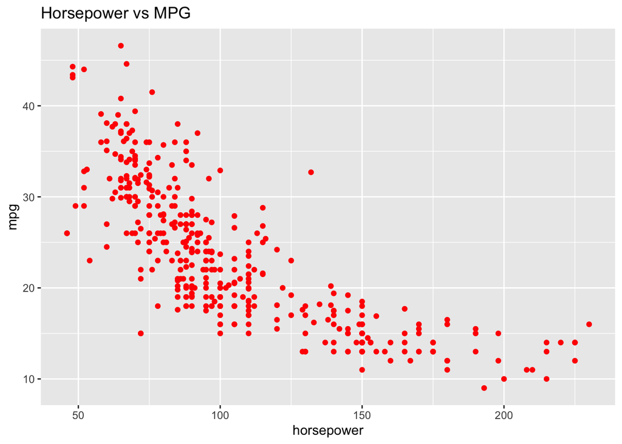

```r
# Scatterplot to show horsepower vs mpg
ggplot(
  data = Auto,
  aes(x = horsepower, y = mpg)) +
  geom_point(color = "red") +
  labs(title = "Horsepower vs MPG")
```

Ans- In this scatter plot, we can see a negative trend and it can be seen that if a car has more horsepower the car consumes more fule so the MPG starts to decrease.

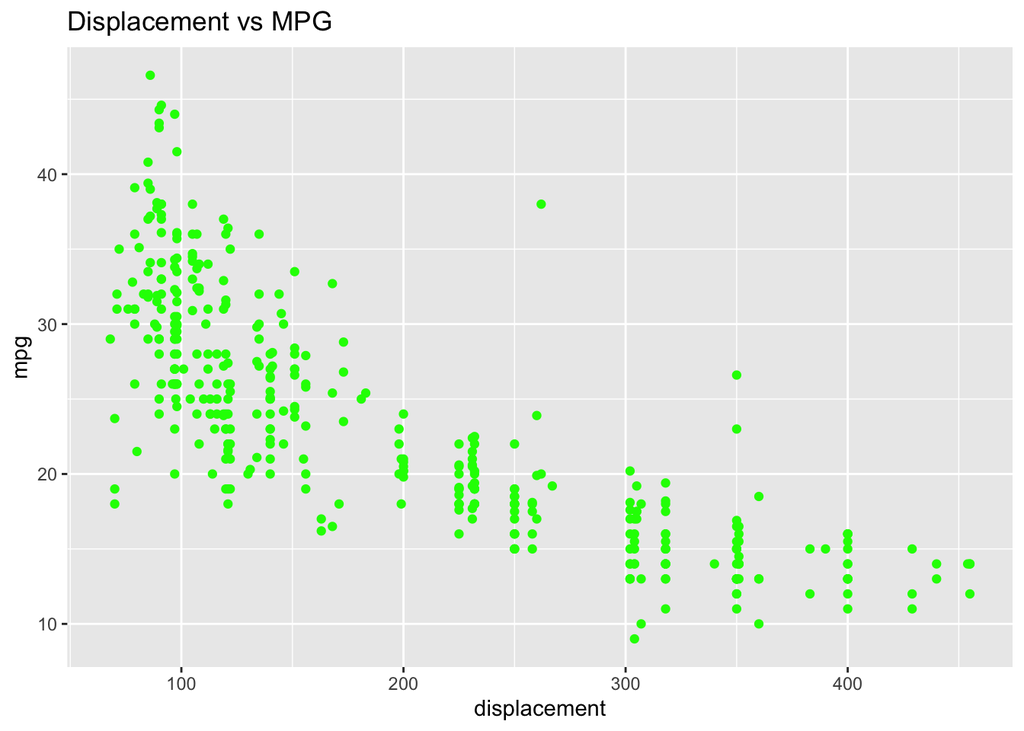

```r
# Scatterplot to show displacement vs mpg
ggplot(
  data = Auto,
  aes(x = displacement, y = mpg)) +
  geom_point(color = "green") +
  labs(title = "Displacement vs MPG")
```

Ans- In this scatter plot, it can be seen that it has a negative trend and if a car has more displacement that is the amount of fuel a car can hold in its cylinders during the maximum power generation the car consumes more fule so as the displacement increases the MPG decreases.

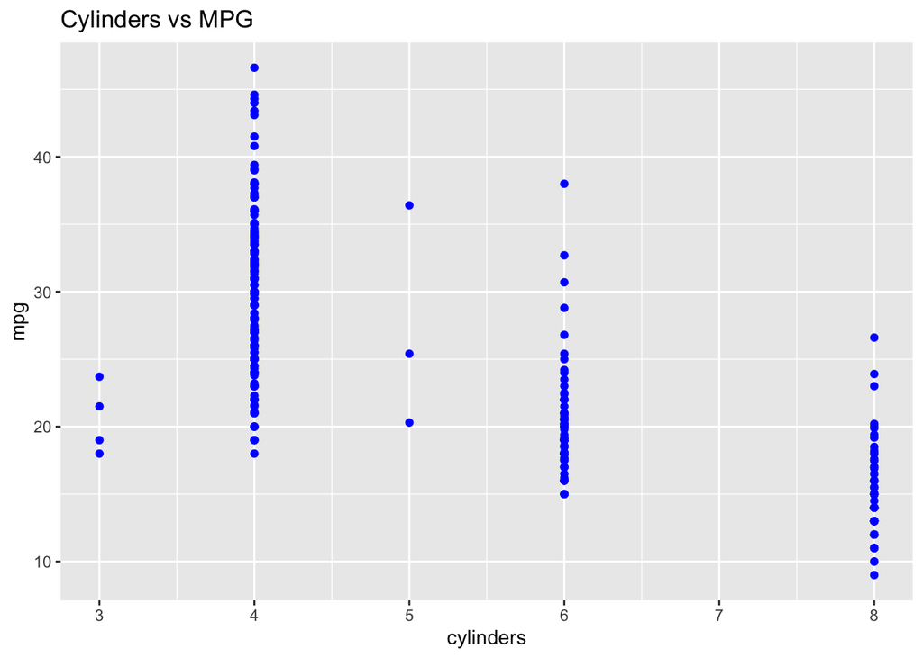

```r
# Scatterplot to show cylinders vs mpg
ggplot(
  data = Auto,
  aes(x = cylinders, y = mpg)) +
  geom_point(color = "blue") +
  labs(title = "Cylinders vs MPG")
```

Ans- In this scatter plot, it can be seen that it has a negative trend and if a car has more number of cylinders it burns more fuel in each cylinder so as the number of cylinders increase the MPG is decreases.

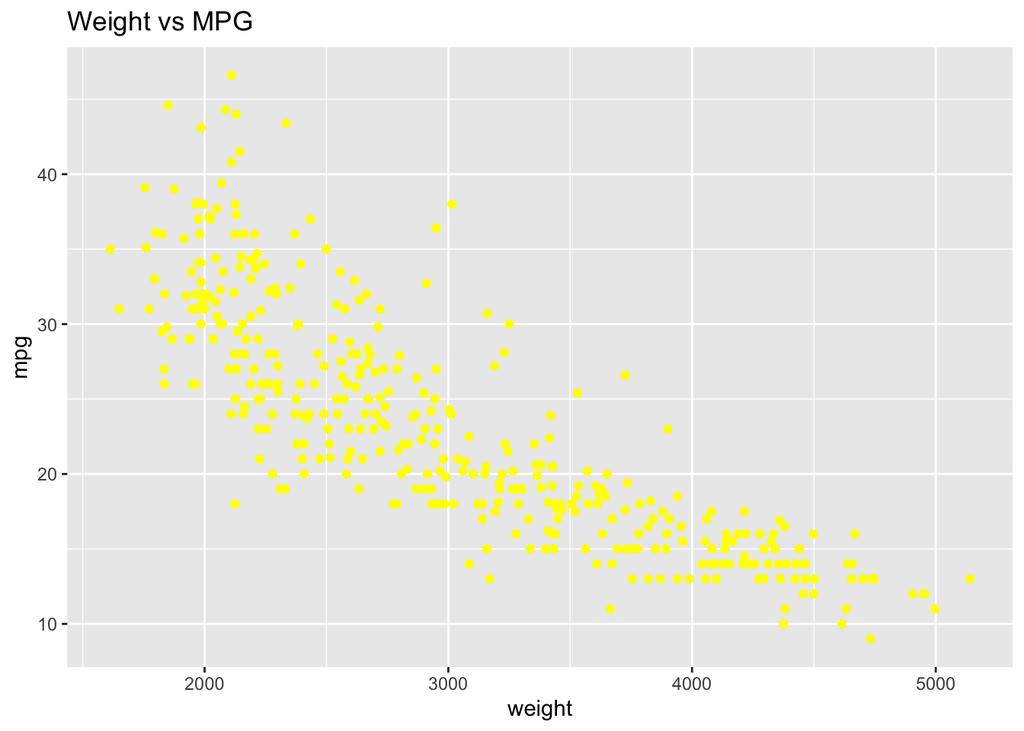

```r
# Scatterplot to show weight vs mpg
ggplot(
  data = Auto,
  aes(x = weight, y = mpg)) +
  geom_point(color = "yellow") +
  labs(title = "Weight vs MPG")
```

Ans- In this scatter plot, it can be seen that it has a negative trend and if a car has more weight it burns more fuel to move that weight so as the weigh increases the MPG decreases.

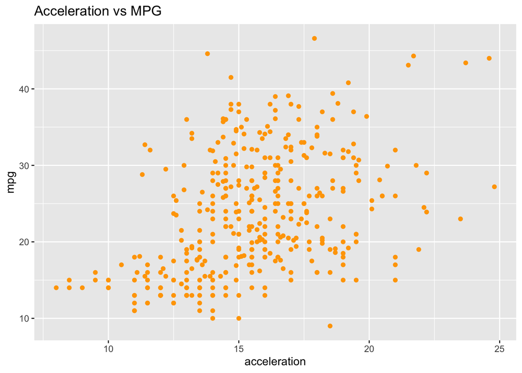

```r
# Scatterplot to show acceleration vs mpg
ggplot(
  data = Auto,
  aes(x = acceleration, y = mpg)) +
  geom_point(color = "orange") +
  labs(title = "Acceleration vs MPG")
```

Ans- In this scatter plot, it can be seen that it has a positive trend and if a car has less acceleration time it burns more fuel quickly so as the acceleration time increases the MPG increases.

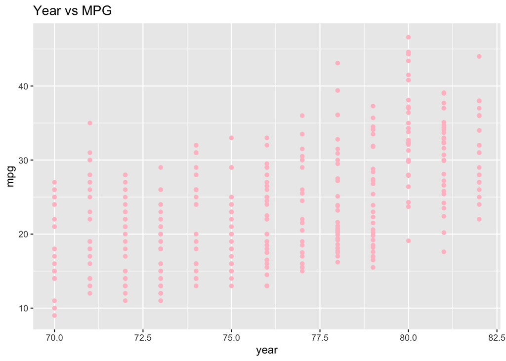

```r
# Scatterplot to show year vs mpg
ggplot(
  data = Auto,
  aes(x = year, y = mpg)) +
  geom_point(color = "pink") +
  labs(title = "Year vs MPG")
```

Ans- In this scatter plot, it can be seen that it has a positive trend which means cars in the older years were less fuel efficient, as the new technology were introduced cars became more efficient and burn less fuel so as the year increases the MPG increases.

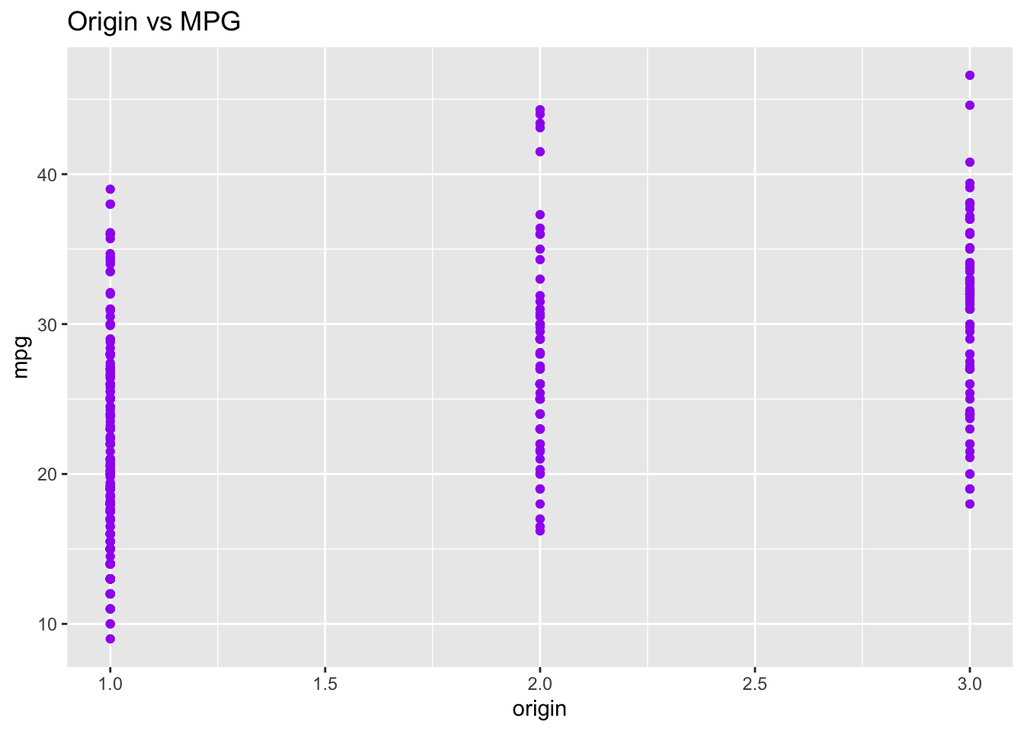

```r
# Scatterplot to show Origin vs mpg
ggplot(
  data = Auto,
  aes(x = origin, y = mpg)) +
  geom_point(color = "purple") +
  labs(title = "Origin vs MPG")
```

Ans- In this scatter plot a positive trend can be seen where Origin of cars are (1. American, 2. European, 3. Japanese) and it can be seen that Japanese cars give better MPG followed by European cars and then American Cars.

=============================================================================================================

# Part II (12 pts + 1 possible extra credit) - Problems from Chapter 3, R for Data Science (2e)Links to an external site.

```r
library(nycflights13)
```

# Q2. - Exercises 3.2.5, Problem 1. (1pt)

In a single pipeline for each condition, find all flights that meet the condition:

1. Had an arrival delay of two or more hours

```r
flights_arrival_delay <- flights |>
  filter(arr_delay >= 120) |>
arrange(desc(arr_delay))
flights_arrival_delay
```

```
## # A tibble: 10,200 × 19
##     year month   day dep_time sched_dep_time dep_delay arr_time sched_arr_time
##    <int> <int> <int>    <int>          <int>     <dbl>    <int>          <int>
##  1  2013     1     9      641            900      1301     1242           1530
##  2  2013     6    15     1432           1935      1137     1607           2120
##  3  2013     1    10     1121           1635      1126     1239           1810
##  4  2013     9    20     1139           1845      1014     1457           2210
##  5  2013     7    22      845           1600      1005     1044           1815
##  6  2013     4    10     1100           1900       960     1342           2211
##  7  2013     3    17     2321            810       911      135           1020
##  8  2013     7    22     2257            759       898      121           1026
##  9  2013    12     5      756           1700       896     1058           2020
## 10  2013     5     3     1133           2055       878     1250           2215
## # ℹ 10,190 more rows
## # ℹ 11 more variables: arr_delay <dbl>, carrier <chr>, flight <int>,
## #   tailnum <chr>, origin <chr>, dest <chr>, air_time <dbl>, distance <dbl>,
## #   hour <dbl>, minute <dbl>, time_hour <dttm>
```

2. Flew to Houston (IAH or HOU)

```r
flights_huston <- flights |>
  filter(dest %in% c("IAH", "HOU"))
flights_huston
```

```
## # A tibble: 9,313 × 19
##     year month   day dep_time sched_dep_time dep_delay arr_time sched_arr_time
##    <int> <int> <int>    <int>          <int>     <dbl>    <int>          <int>
##  1  2013     1     1      517            515         2      830            819
##  2  2013     1     1      533            529         4      850            830
##  3  2013     1     1      623            627        -4      933            932
##  4  2013     1     1      728            732        -4     1041           1038
##  5  2013     1     1      739            739         0     1104           1038
##  6  2013     1     1      908            908         0     1228           1219
##  7  2013     1     1     1028           1026         2     1350           1339
##  8  2013     1     1     1044           1045        -1     1352           1351
##  9  2013     1     1     1114            900       134     1447           1222
## 10  2013     1     1     1205           1200         5     1503           1505
## # ℹ 9,303 more rows
## # ℹ 11 more variables: arr_delay <dbl>, carrier <chr>, flight <int>,
## #   tailnum <chr>, origin <chr>, dest <chr>, air_time <dbl>, distance <dbl>,
## #   hour <dbl>, minute <dbl>, time_hour <dttm>
```

3. Were operated by United, American, or Delta

```r
flights_operators <- flights |>
  filter(carrier %in% c("UA", "AA", "DL"))
flights_operators
```

```
## # A tibble: 139,504 × 19
##     year month   day dep_time sched_dep_time dep_delay arr_time sched_arr_time
##    <int> <int> <int>    <int>          <int>     <dbl>    <int>          <int>
##  1  2013     1     1      517            515         2      830            819
##  2  2013     1     1      533            529         4      850            830
##  3  2013     1     1      542            540         2      923            850
##  4  2013     1     1      554            600        -6      812            837
##  5  2013     1     1      554            558        -4      740            728
##  6  2013     1     1      558            600        -2      753            745
##  7  2013     1     1      558            600        -2      924            917
##  8  2013     1     1      558            600        -2      923            937
##  9  2013     1     1      559            600        -1      941            910
## 10  2013     1     1      559            600        -1      854            902
## # ℹ 139,494 more rows
## # ℹ 11 more variables: arr_delay <dbl>, carrier <chr>, flight <int>,
## #   tailnum <chr>, origin <chr>, dest <chr>, air_time <dbl>, distance <dbl>,
## #   hour <dbl>, minute <dbl>, time_hour <dttm>
```

4. Departed in summer (July, August, and September)

```r
flights_summer <- flights |>
  filter(month %in% c(7, 8, 9))
flights_summer
```

```
## # A tibble: 86,326 × 19
##     year month   day dep_time sched_dep_time dep_delay arr_time sched_arr_time
##    <int> <int> <int>    <int>          <int>     <dbl>    <int>          <int>
##  1  2013     7     1        1           2029       212      236           2359
##  2  2013     7     1        2           2359         3      344            344
##  3  2013     7     1       29           2245       104      151              1
##  4  2013     7     1       43           2130       193      322             14
##  5  2013     7     1       44           2150       174      300            100
##  6  2013     7     1       46           2051       235      304           2358
##  7  2013     7     1       48           2001       287      308           2305
##  8  2013     7     1       58           2155       183      335             43
##  9  2013     7     1      100           2146       194      327             30
## 10  2013     7     1      100           2245       135      337            135
## # ℹ 86,316 more rows
## # ℹ 11 more variables: arr_delay <dbl>, carrier <chr>, flight <int>,
## #   tailnum <chr>, origin <chr>, dest <chr>, air_time <dbl>, distance <dbl>,
## #   hour <dbl>, minute <dbl>, time_hour <dttm>
```

5. Arrived more than two hours late but didn’t leave late

```r
flights_late2 <- flights |>
  filter(arr_delay > 120 , dep_delay <= 0)
flights_late2
```

```
## # A tibble: 29 × 19
##     year month   day dep_time sched_dep_time dep_delay arr_time sched_arr_time
##    <int> <int> <int>    <int>          <int>     <dbl>    <int>          <int>
##  1  2013     1    27     1419           1420        -1     1754           1550
##  2  2013    10     7     1350           1350         0     1736           1526
##  3  2013    10     7     1357           1359        -2     1858           1654
##  4  2013    10    16      657            700        -3     1258           1056
##  5  2013    11     1      658            700        -2     1329           1015
##  6  2013     3    18     1844           1847        -3       39           2219
##  7  2013     4    17     1635           1640        -5     2049           1845
##  8  2013     4    18      558            600        -2     1149            850
##  9  2013     4    18      655            700        -5     1213            950
## 10  2013     5    22     1827           1830        -3     2217           2010
## # ℹ 19 more rows
## # ℹ 11 more variables: arr_delay <dbl>, carrier <chr>, flight <int>,
## #   tailnum <chr>, origin <chr>, dest <chr>, air_time <dbl>, distance <dbl>,
## #   hour <dbl>, minute <dbl>, time_hour <dttm>
```

6. Were delayed by at least an hour, but made up over 30 minutes in flight.

```r
flights_delayed60 <- flights |>
  filter(dep_delay >= 60, (dep_delay - arr_delay) > 30)
flights_delayed60
```

```
## # A tibble: 1,844 × 19
##     year month   day dep_time sched_dep_time dep_delay arr_time sched_arr_time
##    <int> <int> <int>    <int>          <int>     <dbl>    <int>          <int>
##  1  2013     1     1     2205           1720       285       46           2040
##  2  2013     1     1     2326           2130       116      131             18
##  3  2013     1     3     1503           1221       162     1803           1555
##  4  2013     1     3     1839           1700        99     2056           1950
##  5  2013     1     3     1850           1745        65     2148           2120
##  6  2013     1     3     1941           1759       102     2246           2139
##  7  2013     1     3     1950           1845        65     2228           2227
##  8  2013     1     3     2015           1915        60     2135           2111
##  9  2013     1     3     2257           2000       177       45           2224
## 10  2013     1     4     1917           1700       137     2135           1950
## # ℹ 1,834 more rows
## # ℹ 11 more variables: arr_delay <dbl>, carrier <chr>, flight <int>,
## #   tailnum <chr>, origin <chr>, dest <chr>, air_time <dbl>, distance <dbl>,
## #   hour <dbl>, minute <dbl>, time_hour <dttm>
```

=============================================================================================================

# Q3. Exercises 3.2.5, Problem 3. (1pt)

Sort flights to find the fastest flights. (Hint: Try including a math calculation inside of your function.)

```r
fastest_flight <- flights |>
  mutate(speed = (distance/air_time) * 60) |>
arrange(desc(speed)) |>
select(carrier, flight, speed)
fastest_flight
```

```
## # A tibble: 336,776 × 3
##    carrier flight speed
##    <chr>    <int> <dbl>
##  1 DL        1499  703.
##  2 EV        4667  650.
##  3 EV        4292  648
##  4 EV        3805  641.
##  5 DL        1902  591.
##  6 DL         315  564
##  7 B6         707  557.
##  8 AA         936  556.
##  9 DL         347  554.
## 10 B6        1503  554.
## # ℹ 336,766 more rows
```

=============================================================================================================

# Q4. Exercises 3.2.5, Problem 4. (1pt)

Was there a flight on every day of 2013?

```r
flights_2013 <- flights |>
  distinct(year, month, day)
flights_2013
```

```
## # A tibble: 365 × 3
##     year month   day
##    <int> <int> <int>
##  1  2013     1     1
##  2  2013     1     2
##  3  2013     1     3
##  4  2013     1     4
##  5  2013     1     5
##  6  2013     1     6
##  7  2013     1     7
##  8  2013     1     8
##  9  2013     1     9
## 10  2013     1    10
## # ℹ 355 more rows
```

=============================================================================================================

# Q5. Exercises 3.3.5, Problem 1. (1pt)

Compare dep_time, sched_dep_time, and dep_delay. How would you expect those three numbers to be related?

```r
flights_compared <- flights |>
  select(dep_time, sched_dep_time, dep_delay)
flights_compared
```

```
## # A tibble: 336,776 × 3
##    dep_time sched_dep_time dep_delay
##       <int>          <int>     <dbl>
##  1      517            515         2
##  2      533            529         4
##  3      542            540         2
##  4      544            545        -1
##  5      554            600        -6
##  6      554            558        -4
##  7      555            600        -5
##  8      557            600        -3
##  9      557            600        -3
## 10      558            600        -2
## # ℹ 336,766 more rows
```

Ans- The dep_time (actual departure time) is expected to be later than the sched_dep_time (scheduled departure time) when there is a positive dep_delay (departure delay), and they should be equal if there is no delay.

=============================================================================================================

# Q6. Exercises 3.3.5, Problem 3. (1pt)

What happens if you specify the name of the same variable multiple times in a select()Links to an external site. call?

```r
flights_same_variable <- flights |>
  select(carrier, carrier, arr_time)
flights_same_variable
```

```
## # A tibble: 336,776 × 2
##    carrier arr_time
##    <chr>      <int>
##  1 UA           830
##  2 UA           850
##  3 AA           923
##  4 B6          1004
##  5 DL           812
##  6 UA           740
##  7 B6           913
##  8 EV           709
##  9 B6           838
## 10 AA           753
## # ℹ 336,766 more rows
```

Ans- I have picked “carrier” variable two times and we can see that the second variable is being dropped and only one variable is being selected.

=============================================================================================================

Q7. Exercises 3.3.5, Problem 4. (1pt) What does the any_of()Links to an external site. function do? Why might it be helpful in conjunction with this vector?

```
       variables <- c("year", "month", "day", "dep_delay", "arr_delay")
```

```r
variables <- c("year", "month", "day", "dep_delay", "arr_delay")
flights |>
  select(any_of(variables))
```

```
## # A tibble: 336,776 × 5
##     year month   day dep_delay arr_delay
##    <int> <int> <int>     <dbl>     <dbl>
##  1  2013     1     1         2        11
##  2  2013     1     1         4        20
##  3  2013     1     1         2        33
##  4  2013     1     1        -1       -18
##  5  2013     1     1        -6       -25
##  6  2013     1     1        -4        12
##  7  2013     1     1        -5        19
##  8  2013     1     1        -3       -14
##  9  2013     1     1        -3        -8
## 10  2013     1     1        -2         8
## # ℹ 336,766 more rows
```

Ans- The function any_of(variables) will check if each of the column names in the variables vector exists in the flights data frame then select all the columns that are present in flights from the vector variables and ignore any columns in the variables vector that do not exist in flights.

It is helpful because any_of() prevents errors from occurring if any of the specified column names do not exist in the data frame. It allows to select columns dynamically based on a list of variable names, without needing to manually check if each column exists in the data. It can be used in situations where the set of column names might change or where some columns may be missing.

=============================================================================================================

Q8. Exercises 3.3.5, Problem 7. (1pt)

Rename air_time to air_time_min to indicate units of measurement and move it to the beginning of the data frame.

```r
flights |>
  rename(air_time_min = air_time) |>
  relocate(air_time_min)
```

```
## # A tibble: 336,776 × 19
##    air_time_min  year month   day dep_time sched_dep_time dep_delay arr_time
##           <dbl> <int> <int> <int>    <int>          <int>     <dbl>    <int>
##  1          227  2013     1     1      517            515         2      830
##  2          227  2013     1     1      533            529         4      850
##  3          160  2013     1     1      542            540         2      923
##  4          183  2013     1     1      544            545        -1     1004
##  5          116  2013     1     1      554            600        -6      812
##  6          150  2013     1     1      554            558        -4      740
##  7          158  2013     1     1      555            600        -5      913
##  8           53  2013     1     1      557            600        -3      709
##  9          140  2013     1     1      557            600        -3      838
## 10          138  2013     1     1      558            600        -2      753
## # ℹ 336,766 more rows
## # ℹ 11 more variables: sched_arr_time <int>, arr_delay <dbl>, carrier <chr>,
## #   flight <int>, tailnum <chr>, origin <chr>, dest <chr>, distance <dbl>,
## #   hour <dbl>, minute <dbl>, time_hour <dttm>
```

2. Why doesn’t the following work, and what does the error mean?

flights |> selectLinks to an external site.(tailnum) |> arrangeLinks to an external site.(arr_delay) #> Error in `arrange()`: #> ℹ In argument: `..1 = arr_delay`. #> Caused by error: #> ! object ‘arr_delay’ not found

Ans- The error occurs because the tailnum column is being selected with select(tailnum) and then attempting to arrange by arr_delay using arrange(arr_delay).

When select(tailnum) is used, only the tailnum column remains in the data frame, and all other columns are dropped. Since arr_delay is no longer in the data frame after select(), the arrange(arr_delay) call cannot find the arr_delay column, causing the error: object ‘arr_delay’ not found.

=============================================================================================================

Q9. Exercises 3.5.7, Problem 1. (1pt) Which carrier has the worst average delays?

```r
average_delays <- flights |>
  group_by(carrier) |>
  summarize(
    avg_dep_delay = mean(dep_delay, na.rm = TRUE),
    avg_arr_delay = mean(arr_delay, na.rm = TRUE)
  ) |>
  arrange(desc(avg_dep_delay))
average_delays
```

```
## # A tibble: 16 × 3
##    carrier avg_dep_delay avg_arr_delay
##    <chr>           <dbl>         <dbl>
##  1 F9              20.2         21.9
##  2 EV              20.0         15.8
##  3 YV              19.0         15.6
##  4 FL              18.7         20.1
##  5 WN              17.7          9.65
##  6 9E              16.7          7.38
##  7 B6              13.0          9.46
##  8 VX              12.9          1.76
##  9 OO              12.6         11.9
## 10 UA              12.1          3.56
## 11 MQ              10.6         10.8
## 12 DL               9.26         1.64
## 13 AA               8.59         0.364
## 14 AS               5.80        -9.93
## 15 HA               4.90        -6.92
## 16 US               3.78         2.13
```

average_delays

Extra Credit(1pt): Can you disentangle the effects of bad airports vs. bad carriers? Why/why not? Hint: think about

flights |> group_by(carrier, dest) |> summarize(n())

```r
flights |>
  group_by(carrier, dest) |>
  summarize(avg_delay = mean(dep_delay, na.rm = TRUE)) |>
  arrange(desc(avg_delay))
```

```
## # A tibble: 314 × 3
## # Groups:   carrier [16]
##    carrier dest  avg_delay
##    <chr>   <chr>     <dbl>
##  1 UA      STL        77.5
##  2 OO      ORD        67
##  3 OO      DTW        61
##  4 UA      RDU        60
##  5 EV      PBI        48.7
##  6 EV      TYS        41.8
##  7 EV      CAE        36.7
##  8 EV      TUL        34.9
##  9 9E      BGR        34
## 10 WN      MSY        33.4
## # ℹ 304 more rows
```

Ans- Disentangling bad airports vs. bad carriers is challenging in this context because a carrier’s delays can be influenced by factors at the airport (like weather, traffic, or airport operations) and vice versa. For example: Bad airports: An airport with frequent delays due to weather, congestion, or poor infrastructure could cause delays for flights operated by multiple carriers. Bad carriers: A carrier with inefficiencies in operations, maintenance, or scheduling could experience delays regardless of the airport.

=============================================================================================================

Q10. Exercises 3.5.7, Problem 2. (1pt) Find the flights that are most delayed upon departure from each destination.

```r
flights |>
  filter(dep_delay > 0) |>
  group_by(dest) |>
  slice_max(dep_delay, n = 1) |>
  relocate(dest) |>
arrange(desc(dep_delay))
```

```
## # A tibble: 103 × 19
## # Groups:   dest [103]
##    dest   year month   day dep_time sched_dep_time dep_delay arr_time
##    <chr> <int> <int> <int>    <int>          <int>     <dbl>    <int>
##  1 HNL    2013     1     9      641            900      1301     1242
##  2 CMH    2013     6    15     1432           1935      1137     1607
##  3 ORD    2013     1    10     1121           1635      1126     1239
##  4 SFO    2013     9    20     1139           1845      1014     1457
##  5 CVG    2013     7    22      845           1600      1005     1044
##  6 TPA    2013     4    10     1100           1900       960     1342
##  7 MSP    2013     3    17     2321            810       911      135
##  8 PDX    2013     6    27      959           1900       899     1236
##  9 ATL    2013     7    22     2257            759       898      121
## 10 MIA    2013    12     5      756           1700       896     1058
## # ℹ 93 more rows
## # ℹ 11 more variables: sched_arr_time <int>, arr_delay <dbl>, carrier <chr>,
## #   flight <int>, tailnum <chr>, origin <chr>, air_time <dbl>, distance <dbl>,
## #   hour <dbl>, minute <dbl>, time_hour <dttm>
```

=============================================================================================================

Q11. Exercises 3.5.7, Problem 6. (3pt) Suppose we have the following tiny data frame:

df <- tibble Links to an external site.( x = 1:5, y = c Links to an external site.(“a”, “b”, “a”, “a”, “b”), z = c Links to an external site.(“K”, “K”, “L”, “L”, “K”) )

```r
df <- tibble(
  x = 1:5,
  y = c("a", "b", "a", "a", "b"),
  z = c("K", "K", "L", "L", "K")
)
df
```

```
## # A tibble: 5 × 3
##       x y     z
##   <int> <chr> <chr>
## 1     1 a     K
## 2     2 b     K
## 3     3 a     L
## 4     4 a     L
## 5     5 b     K
```

1. (1pt) Write down what you think the output will look like, then check if you were correct, and describe what group_by()Links to an external site. does.

Ans- It will create a 5 row and 3 column data frame with x,y and z variables where x will contain numbers from 1 - 5, y will contain values mentioned above i.e. (a,b,a,a,b) and z will contain values(K,K,L,L,K).

df |> group_by Links to an external site.(y)

```r
df |>
  group_by(y)
```

```
## # A tibble: 5 × 3
## # Groups:   y [2]
##       x y     z
##   <int> <chr> <chr>
## 1     1 a     K
## 2     2 b     K
## 3     3 a     L
## 4     4 a     L
## 5     5 b     K
```

=============================================================================================================

2. (1pt) Write down what you think the output will look like, then check if you were correct, and describe what arrange()Links to an external site. does. Also, comment on how it’s different from the group_by()Links to an external site. in part (a).

df |> arrangeLinks to an external site.(y)

Ans- We should have the tibble similar to question “a” before group_by i.e. It will create a 5 row and 3 column data frame with x,y and z variables where x will contain numbers from 1 - 5, y will contain values mentioned above i.e. (a,b,a,a,b) and z will contain values(K,K,L,L,K).

When we use arrange(y) to Link to an external site the output will reorder the rows based on the values in the y column in ascending order (default behavior). Since “a” comes before “b” alphabetically, we expect all the rows with y = “a” to come first, followed by the rows with y = “b”. So, the resulting tibble will look like this: (y = a,a,a,b,b)

group_by() groups the data by one or more variables, preparing it for subsequent operations that will be applied within each group. It does not change the order of the rows in the data frame.

arrange() reorders the rows of the data frame based on one or more columns, but it does not group the data in preparation for subsequent operations like group_by() does.

```r
df |>
  arrange(y)
```

```
## # A tibble: 5 × 3
##       x y     z
##   <int> <chr> <chr>
## 1     1 a     K
## 2     3 a     L
## 3     4 a     L
## 4     2 b     K
## 5     5 b     K
```

=============================================================================================================

6. (1pt) Write down what you think the outputs will look like, then check if you were correct, and describe what each pipeline does. How are the outputs of the two pipelines different?

df |> group_by Links to an external site.(y, z) |> summarize Links to an external site.(mean_x = mean Links to an external site.(x))

Ans- This pipeline groups the data by the y and z columns, and then calculates the mean of the x values within each group. The output will show one row for each unique combination of y and z, with the corresponding mean of x. Since y has two unique values (“a” and “b”) and z has two unique values (“K” and “L”), the resulting output will be a summarized table with unique combinations of y and z, and the mean of x for each combination.

```r
df |>
  group_by(y, z) |>
  summarize(mean_x = mean(x))
```

[output not shown]

```
## # A tibble: 3 × 3
## # Groups:   y [2]
##   y     z     mean_x
##   <chr> <chr>  <dbl>
## 1 a     K        1
## 2 a     L        3.5
## 3 b     K        3.5
```

df |> group_by Links to an external site.(y, z) |> mutate Links to an external site.(mean_x = mean Links to an external site.(x))

This pipeline also groups the data by y and z, but instead of summarizing the data, it calculates the mean of x within each group and adds a new column (mean_x) to the original data frame. Every row in a particular group will get the same value of mean_x (the mean of x for that group).

```r
df |>
  group_by(y, z) |>
  mutate(mean_x = mean(x))
```

```
## # A tibble: 5 × 4
## # Groups:   y, z [3]
##       x y     z     mean_x
##   <int> <chr> <chr>  <dbl>
## 1     1 a     K        1
## 2     2 b     K        3.5
## 3     3 a     L        3.5
## 4     4 a     L        3.5
## 5     5 b     K        3.5
```

Pipeline 1 (summarize()): The output is a summarized data frame where each row represents a unique combination of the grouping variables (y and z), and the mean_x value is calculated for each combination of y and z.

Pipeline 2 (mutate()): The output is the original data frame, but with a new column mean_x that contains the mean of x within each group. The mean_x values are repeated across rows within the same group.